# Biostat 212a Homework 5

Due Mar 11, 2024 @ 11:59PM

Author

Yuhui Wang, UID: 606332401

Published

March 13, 2024

## 1 ISL Exercise 9.7.1 (10pts)

> This problem involves hyperplanes in two dimensions.
> 1. Sketch the hyperplane $1 + 3X_1 − X_2 = 0$. Indicate the set of points for which $1 + 3X_1 − X_2 > 0$, as well as the set of points for which $1 + 3X_1 − X_2 < 0$.

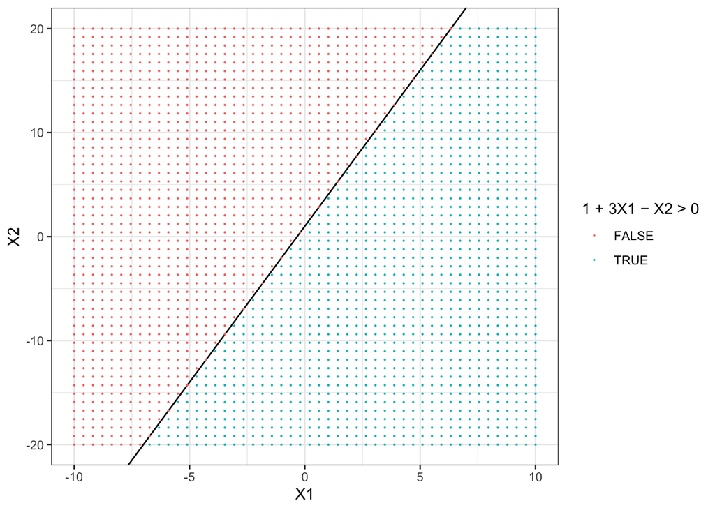

```r
library(ggplot2)
xlim <- c(-10, 10)
ylim <- c(-20, 20)
points <- expand.grid(
  X1 = seq(xlim[1], xlim[2], length.out = 50),
  X2 = seq(ylim[1], ylim[2], length.out = 50)
)

#hyperplane
plane <- ggplot(points, aes(x = X1, y = X2)) +
  geom_abline(intercept = 1, slope = 3) +
  theme_bw()

plane + geom_point(aes(color = 1 + 3*X1 - X2 > 0), size = 0.1) +
  scale_color_discrete(name = "1 + 3X1 − X2 > 0")
```

> 2. On the same plot, sketch the hyperplane $−2 + X_1 + 2X_2 = 0$. Indicate the set of points for which $−2 + X_1 + 2X_2 > 0$, as well as the set of points for which $−2 + X_1 + 2X_2 < 0$.

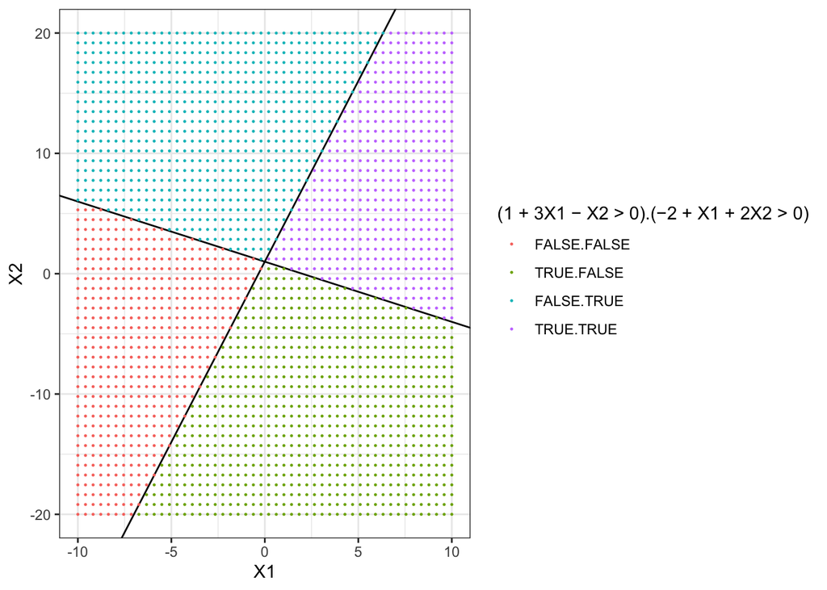

```r
plane + geom_abline(intercept = 1, slope = -1/2) +  # X2 = 1 - X1/2
  geom_point(
    aes(color = interaction(1 + 3*X1 - X2 > 0, -2 + X1 + 2*X2 > 0)),
    size = 0.2
  ) +
  scale_color_discrete(name = "(1 + 3X1 − X2 > 0).(−2 + X1 + 2X2 > 0)")
```

## 2 ISL Exercise 9.7.2 (10pts)

> We have seen that in $p = 2$ dimensions, a linear decision boundary takes the form $\beta_0 + \beta_1X_1 + \beta_2X_2 = 0$. We now investigate a non-linear decision boundary.
> 1. Sketch the curve
>    $$(1+X_1)^2 +(2−X_2)^2 = 4$$
>    .

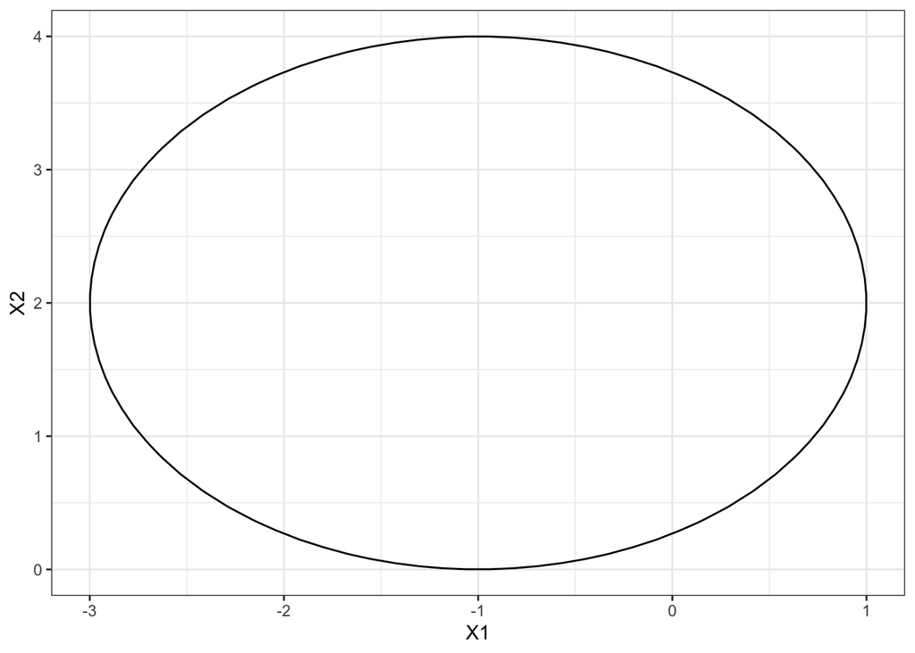

```r
points <- expand.grid(
  X1 = seq(-4, 2, length.out = 50),
  X2 = seq(-1, 5, length.out = 50)
)
plane <- ggplot(points, aes(x = X1, y = X2,
                            z = (1 + X1)^2 + (2 - X2)^2 - 4)) +
  geom_contour(breaks = 0, colour = "black") +
  theme_bw()
plane
```

> 2. On your sketch, indicate the set of points for which
>    $$(1 + X_1)^2 + (2 − X_2)^2 > 4,$$
>    as well as the set of points for which
>    $$(1 + X_1)^2 + (2 − X_2)^2 \leq 4.$$

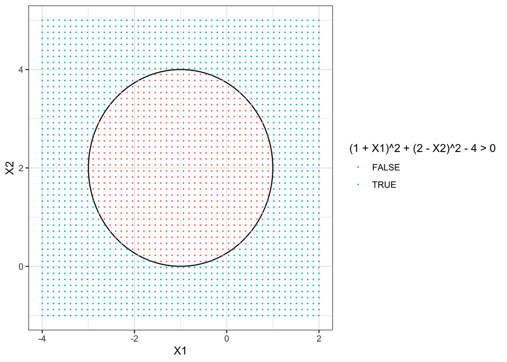

```r
plane + geom_point(aes(color = (1 + X1)^2 + (2 - X2)^2 - 4 > 0),
                   size = 0.1)
```

> 3. Suppose that a classifier assigns an observation to the blue class if
>    $$(1
>    + X_1)^2 + (2 − X_2)^2 > 4,$$
>    and to the red class otherwise. To what class is the observation $(0, 0)$ classified? $(−1, 1)$? $(2, 2)$? $(3, 8)$?

```r
points <- data.frame(
  X1 = c(0, -1, 2, 3),
  X2 = c(0, 1, 2, 8)
)
print(ifelse((1 + points$X1)^2 + (2 - points$X2)^2 > 4, "blue", "red"))
```

```
[1] "blue" "red"  "blue" "blue"
```

> 4. Argue that while the decision boundary in (c) is not linear in terms of $X_1$ and $X_2$, it is linear in terms of $X_1$, $X_1^2$, $X_2$, and $X_2^2$.

For this question, the decision boundary is defined as:
$$(1 + X_1)^2 + (2 − X_2)^2 -4 = 0$$
And we can expand the equation to:
$$1 + 2X_1 + X_1^2 + 4 − 4X_2 + X_2^2 - 4 = 0$$
For this equation, it is linear in terms of $X_1$, $X_1^2$, $X_2$, $X_2^2$.

## 3 Support vector machines (SVMs) on the `Carseats` data set (30pts)

Follow the machine learning workflow to train support vector classifier (same as SVM with linear kernel), SVM with polynomial kernel (tune the degree and regularization parameter $C$), and SVM with radial kernel (tune the scale parameter $\gamma$ and regularization parameter $C$) for classifying `Sales<=8` versus `Sales>8`. Use the same seed as in your HW4 for the initial test/train split and compare the final test AUC and accuracy to those methods you tried in HW4.

```r
library(ISLR2)
library(GGally)
library(gtsummary)
library(kernlab)
library(tidyverse)
library(tidymodels)
```

Initial split into test and non-test sets:

```r
Carseats <- Carseats %>%
  mutate(Sales = ifelse(Sales <= 8, "Low", "High"))
Carseats %>% tbl_summary(by = Sales)
```

| **Characteristic** | **High**, N = 164<sup>1</sup> | **Low**, N = 236<sup>1</sup> |
| --- | --- | --- |
| CompPrice | 127 (115, 136) | 124 (115, 134) |
| Income | 76 (58, 94) | 65 (40, 88) |
| Advertising | 10.0 (0.0, 14.0) | 3.0 (0.0, 10.0) |
| Population | 276 (150, 403) | 268 (132, 389) |
| Price | 107 (90, 123) | 122 (107, 135) |
| ShelveLoc |  |  |
| Bad | 14 (8.5%) | 82 (35%) |
| Good | 66 (40%) | 19 (8.1%) |
| Medium | 84 (51%) | 135 (57%) |
| Age | 49 (36, 61) | 58 (42, 70) |
| Education |  |  |
| 10 | 25 (15%) | 23 (9.7%) |
| 11 | 17 (10%) | 31 (13%) |
| 12 | 19 (12%) | 30 (13%) |
| 13 | 17 (10%) | 26 (11%) |
| 14 | 14 (8.5%) | 26 (11%) |
| 15 | 18 (11%) | 18 (7.6%) |
| 16 | 18 (11%) | 29 (12%) |
| 17 | 21 (13%) | 28 (12%) |
| 18 | 15 (9.1%) | 25 (11%) |
| Urban | 110 (67%) | 172 (73%) |
| US | 123 (75%) | 135 (57%) |

<sup>1</sup> Median (IQR); n (%)

```r
set.seed(2)
data_split <- initial_split(
  Carseats,
  strata = "Sales",
  prop = 0.9
  )
data_split
```

```
<Training/Testing/Total>
<359/41/400>
```

```r
Carseats_other <- training(data_split)
dim(Carseats_other)
```

```
[1] 359  11
```

```r
Carseats_test <- testing(data_split)
dim(Carseats_test)
```

```
[1] 41 11
```

Recipe

```r
svm_recipe <-
  recipe(
    Sales ~ .,
    data = Carseats_other
  ) %>%
  # create traditional dummy variables (necessary for svm)
  step_dummy(all_nominal_predictors()) %>%
  # zero-variance filter
  step_zv(all_numeric_predictors()) %>%
  # center and scale numeric data
  step_normalize(all_numeric_predictors())

svm_recipe
```

Model radial kernel

```r
svm_mod <-
  svm_rbf(
    mode = "classification",
    cost = tune(),
    rbf_sigma = tune()
  ) %>%
  set_engine("kernlab")
svm_mod
```

```
Radial Basis Function Support Vector Machine Model Specification (classification)

Main Arguments:
  cost = tune()
  rbf_sigma = tune()

Computational engine: kernlab
```

Workflow

```r
svm_wf <- workflow() %>%
  add_recipe(svm_recipe) %>%
  add_model(svm_mod)
svm_wf
```

```
══ Workflow ════════════════════════════════════════════════════════════════════
Preprocessor: Recipe
Model: svm_rbf()

── Preprocessor ────────────────────────────────────────────────────────────────
3 Recipe Steps

• step_dummy()
• step_zv()
• step_normalize()

── Model ───────────────────────────────────────────────────────────────────────
Radial Basis Function Support Vector Machine Model Specification (classification)

Main Arguments:
  cost = tune()
  rbf_sigma = tune()

Computational engine: kernlab
```

Tune

```r
param_grid <- grid_regular(
  cost(range = c(-8, 10)),
  rbf_sigma(range = c(-5, -2)),
  levels = c(14, 5)
  )
param_grid
```

```
# A tibble: 70 × 2
       cost rbf_sigma
      <dbl>     <dbl>
 1  0.00391   0.00001
 2  0.0102    0.00001
 3  0.0266    0.00001
 4  0.0695    0.00001
 5  0.182     0.00001
 6  0.474     0.00001
 7  1.24      0.00001
 8  3.23      0.00001
 9  8.44      0.00001
10 22.0       0.00001
# ℹ 60 more rows
```

Cross-validation

```r
set.seed(2)

folds <- vfold_cv(Carseats_other, v = 5)
folds
```

```
#  5-fold cross-validation
# A tibble: 5 × 2
  splits           id
  <list>           <chr>
1 <split [287/72]> Fold1
2 <split [287/72]> Fold2
3 <split [287/72]> Fold3
4 <split [287/72]> Fold4
5 <split [288/71]> Fold5
```

```r
svm_fit <- svm_wf %>%
  tune_grid(
    resamples = folds,
    grid = param_grid,
    metrics = metric_set(roc_auc, accuracy)
    )
svm_fit
```

```
# Tuning results
# 5-fold cross-validation
# A tibble: 5 × 4
  splits           id    .metrics           .notes
  <list>           <chr> <list>             <list>
1 <split [287/72]> Fold1 <tibble [140 × 6]> <tibble [0 × 3]>
2 <split [287/72]> Fold2 <tibble [140 × 6]> <tibble [0 × 3]>
3 <split [287/72]> Fold3 <tibble [140 × 6]> <tibble [0 × 3]>
4 <split [287/72]> Fold4 <tibble [140 × 6]> <tibble [0 × 3]>
5 <split [288/71]> Fold5 <tibble [140 × 6]> <tibble [0 × 3]>
```

```
# A tibble: 140 × 8
      cost rbf_sigma .metric  .estimator  mean     n std_err
     <dbl>     <dbl> <chr>    <chr>      <dbl> <int>   <dbl>
 1 0.00391   0.00001 accuracy binary     0.591     5  0.0212
 2 0.00391   0.00001 roc_auc  binary     0.876     5  0.0127
 3 0.0102    0.00001 accuracy binary     0.591     5  0.0212
 4 0.0102    0.00001 roc_auc  binary     0.876     5  0.0127
 5 0.0266    0.00001 accuracy binary     0.591     5  0.0212
 6 0.0266    0.00001 roc_auc  binary     0.876     5  0.0127
 7 0.0695    0.00001 accuracy binary     0.591     5  0.0212
 8 0.0695    0.00001 roc_auc  binary     0.876     5  0.0127
 9 0.182     0.00001 accuracy binary     0.591     5  0.0212
10 0.182     0.00001 roc_auc  binary     0.876     5  0.0127
   .config
   <chr>
 1 Preprocessor1_Model01
 2 Preprocessor1_Model01
 3 Preprocessor1_Model02
 4 Preprocessor1_Model02
 5 Preprocessor1_Model03
 6 Preprocessor1_Model03
 7 Preprocessor1_Model04
 8 Preprocessor1_Model04
 9 Preprocessor1_Model05
10 Preprocessor1_Model05
# ℹ 130 more rows
```

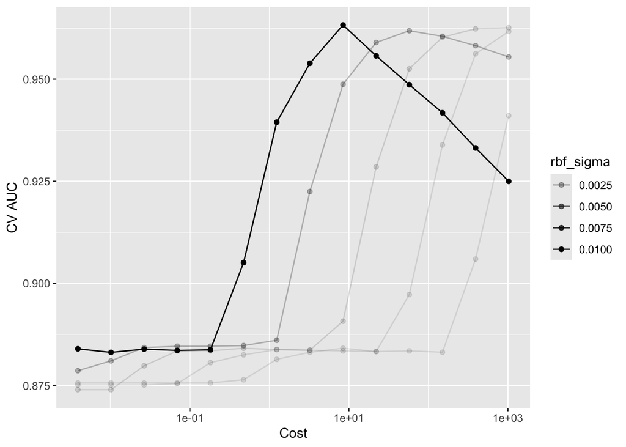

```r
svm_fit %>%
  collect_metrics() %>%
  print(width = Inf) %>%
  filter(.metric == "roc_auc") %>%
  ggplot(mapping = aes(x = cost, y = mean, alpha = rbf_sigma)) +
  geom_point() +
  geom_line(aes(group = rbf_sigma)) +
  labs(x = "Cost", y = "CV AUC") +
  scale_x_log10()
```

```r
svm_fit %>%
  show_best("roc_auc")
```

```
# A tibble: 5 × 8
     cost rbf_sigma .metric .estimator  mean     n std_err .config
    <dbl>     <dbl> <chr>   <chr>      <dbl> <int>   <dbl> <chr>
1    8.44 0.01      roc_auc binary     0.963     5 0.00448 Preprocessor1_Model65
2 1024    0.000316  roc_auc binary     0.963     5 0.00381 Preprocessor1_Model42
3  392.   0.000316  roc_auc binary     0.962     5 0.00509 Preprocessor1_Model41
4   57.5  0.00178   roc_auc binary     0.962     5 0.00451 Preprocessor1_Model53
5 1024    0.0000562 roc_auc binary     0.962     5 0.00456 Preprocessor1_Model28
```

```r
best_svm <- svm_fit %>%
  select_best("roc_auc")
best_svm
```

```
# A tibble: 1 × 3
   cost rbf_sigma .config
  <dbl>     <dbl> <chr>
1  8.44      0.01 Preprocessor1_Model65
```

Finalize the model

```r
# Final workflow
final_wf <- svm_wf %>%
  finalize_workflow(best_svm)
final_wf
```

```
══ Workflow ════════════════════════════════════════════════════════════════════
Preprocessor: Recipe
Model: svm_rbf()

── Preprocessor ────────────────────────────────────────────────────────────────
3 Recipe Steps

• step_dummy()
• step_zv()
• step_normalize()

── Model ───────────────────────────────────────────────────────────────────────
Radial Basis Function Support Vector Machine Model Specification (classification)

Main Arguments:
  cost = 8.43812861185317
  rbf_sigma = 0.01

Computational engine: kernlab
```

```r
# Fit the whole training set, then predict the test cases
final_fit <-
  final_wf %>%
  last_fit(data_split)
final_fit
```

```
# Resampling results
# Manual resampling
# A tibble: 1 × 6
  splits           id               .metrics .notes   .predictions .workflow
  <list>           <chr>            <list>   <list>   <list>       <list>
1 <split [359/41]> train/test split <tibble> <tibble> <tibble>     <workflow>
```

```r
# Test metrics
final_fit %>%
  collect_metrics()
```

```
# A tibble: 2 × 4
  .metric  .estimator .estimate .config
  <chr>    <chr>          <dbl> <chr>
1 accuracy binary         0.902 Preprocessor1_Model1
2 roc_auc  binary         0.971 Preprocessor1_Model1
```

Model with polynomial kernel

Linear:

```r
svm_mod_l <-
  svm_poly(
    mode = "classification",
    cost = tune(),
    degree = tune(),
    # scale_factor = tune()
  ) %>%
  set_engine("kernlab")
svm_mod_l
```

```
Polynomial Support Vector Machine Model Specification (classification)

Main Arguments:
  cost = tune()
  degree = tune()

Computational engine: kernlab
```

```r
svm_wf_l <- workflow() %>%
  add_recipe(svm_recipe) %>%
  add_model(svm_mod_l)
svm_wf_l
```

```
══ Workflow ════════════════════════════════════════════════════════════════════
Preprocessor: Recipe
Model: svm_poly()

── Preprocessor ────────────────────────────────────────────────────────────────
3 Recipe Steps

• step_dummy()
• step_zv()
• step_normalize()

── Model ───────────────────────────────────────────────────────────────────────
Polynomial Support Vector Machine Model Specification (classification)

Main Arguments:
  cost = tune()
  degree = tune()

Computational engine: kernlab
```

```r
param_grid_l <- grid_regular(
  cost(range = c(-5, 2)),
  degree(range = c(1,1)),
  #scale_factor(range = c(-1, 1)),
  levels = c(5)
  )
param_grid_l
```

```
# A tibble: 5 × 2
    cost degree
   <dbl>  <dbl>
1 0.0312      1
2 0.105       1
3 0.354       1
4 1.19        1
5 4           1
```

```r
svm_fit_l <- svm_wf_l %>%
  tune_grid(
    resamples = folds,
    grid = param_grid_l,
    metrics = metric_set(roc_auc, accuracy)
    )
svm_fit_l
```

```
# Tuning results
# 5-fold cross-validation
# A tibble: 5 × 4
  splits           id    .metrics          .notes
  <list>           <chr> <list>            <list>
1 <split [287/72]> Fold1 <tibble [10 × 6]> <tibble [0 × 3]>
2 <split [287/72]> Fold2 <tibble [10 × 6]> <tibble [0 × 3]>
3 <split [287/72]> Fold3 <tibble [10 × 6]> <tibble [0 × 3]>
4 <split [287/72]> Fold4 <tibble [10 × 6]> <tibble [0 × 3]>
5 <split [288/71]> Fold5 <tibble [10 × 6]> <tibble [0 × 3]>
```

```
# A tibble: 10 × 8
     cost degree .metric  .estimator  mean     n std_err .config
    <dbl>  <dbl> <chr>    <chr>      <dbl> <int>   <dbl> <chr>
 1 0.0312      1 accuracy binary     0.872     5 0.0183  Preprocessor1_Model1
 2 0.0312      1 roc_auc  binary     0.952     5 0.00563 Preprocessor1_Model1
 3 0.105       1 accuracy binary     0.875     5 0.0152  Preprocessor1_Model2
 4 0.105       1 roc_auc  binary     0.961     5 0.00416 Preprocessor1_Model2
 5 0.354       1 accuracy binary     0.880     5 0.0143  Preprocessor1_Model3
 6 0.354       1 roc_auc  binary     0.962     5 0.00415 Preprocessor1_Model3
 7 1.19        1 accuracy binary     0.886     5 0.00933 Preprocessor1_Model4
 8 1.19        1 roc_auc  binary     0.961     5 0.00424 Preprocessor1_Model4
 9 4           1 accuracy binary     0.886     5 0.0120  Preprocessor1_Model5
10 4           1 roc_auc  binary     0.960     5 0.00447 Preprocessor1_Model5
```

[figure not shown]

```r
svm_fit_l %>%
  collect_metrics() %>%
  print(width = Inf) %>%
  filter(.metric == "roc_auc" ) %>%
  ggplot(mapping = aes(x = degree, y = mean)) +
  geom_point() +
  geom_line() +
  labs(x = "Cost", y = "CV AUC") +
  scale_x_log10()
```

```r
best_svm_l <- svm_fit_l %>%
  select_best("roc_auc")
best_svm_l
```

```
# A tibble: 1 × 3
   cost degree .config
  <dbl>  <dbl> <chr>
1 0.354      1 Preprocessor1_Model3
```

```r
final_wf_l <- svm_wf_l %>%
  finalize_workflow(best_svm_l)
final_wf_l
```

```
══ Workflow ════════════════════════════════════════════════════════════════════
Preprocessor: Recipe
Model: svm_poly()

── Preprocessor ────────────────────────────────────────────────────────────────
3 Recipe Steps

• step_dummy()
• step_zv()
• step_normalize()

── Model ───────────────────────────────────────────────────────────────────────
Polynomial Support Vector Machine Model Specification (classification)

Main Arguments:
  cost = 0.353553390593274
  degree = 1

Computational engine: kernlab
```

```r
final_fit_l <-
  final_wf_l %>%
  last_fit(data_split)
final_fit_l
```

```
# Resampling results
# Manual resampling
# A tibble: 1 × 6
  splits           id               .metrics .notes   .predictions .workflow
  <list>           <chr>            <list>   <list>   <list>       <list>
1 <split [359/41]> train/test split <tibble> <tibble> <tibble>     <workflow>
```

```r
final_fit_l %>%
  collect_metrics()
```

```
# A tibble: 2 × 4
  .metric  .estimator .estimate .config
  <chr>    <chr>          <dbl> <chr>
1 accuracy binary         0.902 Preprocessor1_Model1
2 roc_auc  binary         0.971 Preprocessor1_Model1
```

Non linear:

```r
svm_mod_p <-
  svm_poly(
    mode = "classification",
    cost = tune(),
    degree = tune(),
    # scale_factor = tune()
  ) %>%
  set_engine("kernlab")
svm_mod_p
```

```
Polynomial Support Vector Machine Model Specification (classification)

Main Arguments:
  cost = tune()
  degree = tune()

Computational engine: kernlab
```

```r
svm_wf_p <- workflow() %>%
  add_recipe(svm_recipe) %>%
  add_model(svm_mod_p)
svm_wf_p
```

```
══ Workflow ════════════════════════════════════════════════════════════════════
Preprocessor: Recipe
Model: svm_poly()

── Preprocessor ────────────────────────────────────────────────────────────────
3 Recipe Steps

• step_dummy()
• step_zv()
• step_normalize()

── Model ───────────────────────────────────────────────────────────────────────
Polynomial Support Vector Machine Model Specification (classification)

Main Arguments:
  cost = tune()
  degree = tune()

Computational engine: kernlab
```

```r
param_grid_p <- grid_regular(
  cost(range = c(-5, 2)),
  degree(range = c(1, 5)),
  #scale_factor(range = c(-1, 1)),
  levels = c(5)
  )
param_grid_p
```

```
# A tibble: 25 × 2
     cost degree
    <dbl>  <dbl>
 1 0.0312      1
 2 0.105       1
 3 0.354       1
 4 1.19        1
 5 4           1
 6 0.0312      2
 7 0.105       2
 8 0.354       2
 9 1.19        2
10 4           2
# ℹ 15 more rows
```

```r
svm_fit_p <- svm_wf_p %>%
  tune_grid(
    resamples = folds,
    grid = param_grid_p,
    metrics = metric_set(roc_auc, accuracy)
    )
svm_fit_p
```

```
# Tuning results
# 5-fold cross-validation
# A tibble: 5 × 4
  splits           id    .metrics          .notes
  <list>           <chr> <list>            <list>
1 <split [287/72]> Fold1 <tibble [50 × 6]> <tibble [0 × 3]>
2 <split [287/72]> Fold2 <tibble [50 × 6]> <tibble [0 × 3]>
3 <split [287/72]> Fold3 <tibble [50 × 6]> <tibble [0 × 3]>
4 <split [287/72]> Fold4 <tibble [50 × 6]> <tibble [0 × 3]>
5 <split [288/71]> Fold5 <tibble [50 × 6]> <tibble [0 × 3]>
```

```
# A tibble: 50 × 8
     cost degree .metric  .estimator  mean     n std_err .config
    <dbl>  <dbl> <chr>    <chr>      <dbl> <int>   <dbl> <chr>
 1 0.0312      1 accuracy binary     0.872     5 0.0183  Preprocessor1_Model01
 2 0.0312      1 roc_auc  binary     0.952     5 0.00563 Preprocessor1_Model01
 3 0.105       1 accuracy binary     0.875     5 0.0152  Preprocessor1_Model02
 4 0.105       1 roc_auc  binary     0.961     5 0.00416 Preprocessor1_Model02
 5 0.354       1 accuracy binary     0.880     5 0.0143  Preprocessor1_Model03
 6 0.354       1 roc_auc  binary     0.962     5 0.00415 Preprocessor1_Model03
 7 1.19        1 accuracy binary     0.886     5 0.00933 Preprocessor1_Model04
 8 1.19        1 roc_auc  binary     0.961     5 0.00424 Preprocessor1_Model04
 9 4           1 accuracy binary     0.886     5 0.0120  Preprocessor1_Model05
10 4           1 roc_auc  binary     0.960     5 0.00447 Preprocessor1_Model05
# ℹ 40 more rows
```

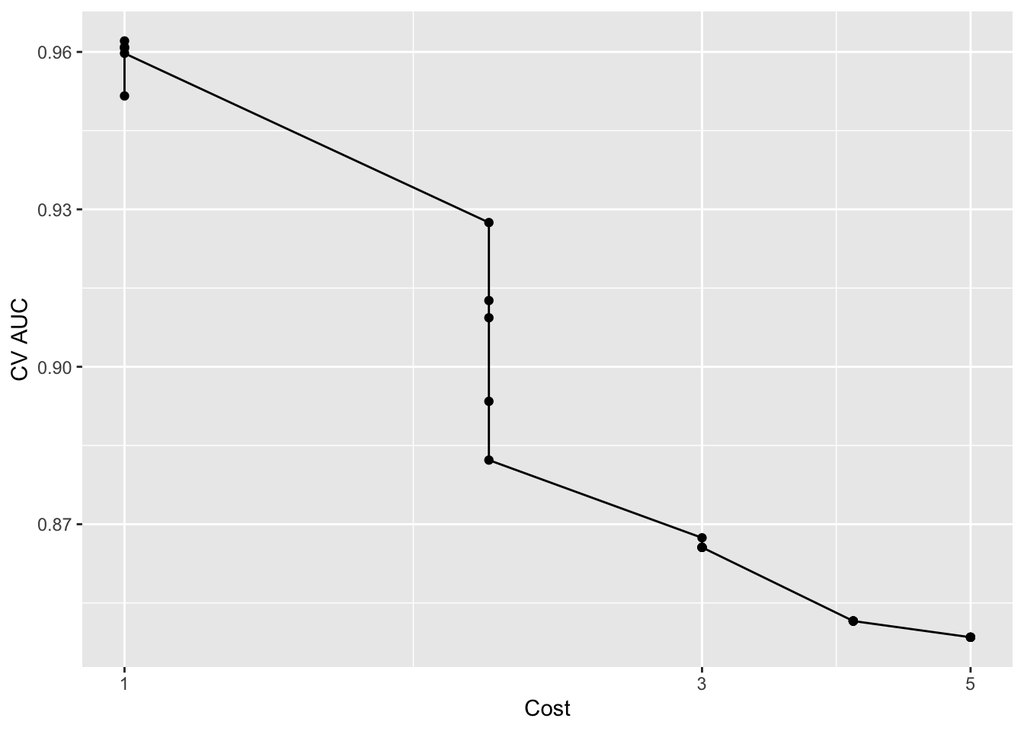

```r
svm_fit_p %>%
  collect_metrics() %>%
  print(width = Inf) %>%
  filter(.metric == "roc_auc" ) %>%
  ggplot(mapping = aes(x = degree, y = mean)) +
  geom_point() +
  geom_line() +
  labs(x = "Cost", y = "CV AUC") +
  scale_x_log10()
```

```r
svm_fit_p %>%
  show_best("roc_auc")
```

```
# A tibble: 5 × 8
    cost degree .metric .estimator  mean     n std_err .config
   <dbl>  <dbl> <chr>   <chr>      <dbl> <int>   <dbl> <chr>
1 0.354       1 roc_auc binary     0.962     5 0.00415 Preprocessor1_Model03
2 0.105       1 roc_auc binary     0.961     5 0.00416 Preprocessor1_Model02
3 1.19        1 roc_auc binary     0.961     5 0.00424 Preprocessor1_Model04
4 4           1 roc_auc binary     0.960     5 0.00447 Preprocessor1_Model05
5 0.0312      1 roc_auc binary     0.952     5 0.00563 Preprocessor1_Model01
```

```r
best_svm_p <- svm_fit_p %>%
  select_best("roc_auc")
best_svm_p
```

```
# A tibble: 1 × 3
   cost degree .config
  <dbl>  <dbl> <chr>
1 0.354      1 Preprocessor1_Model03
```

```r
final_wf_p <- svm_wf_p %>%
  finalize_workflow(best_svm_p)
final_wf_p
```

```
══ Workflow ════════════════════════════════════════════════════════════════════
Preprocessor: Recipe
Model: svm_poly()

── Preprocessor ────────────────────────────────────────────────────────────────
3 Recipe Steps

• step_dummy()
• step_zv()
• step_normalize()

── Model ───────────────────────────────────────────────────────────────────────
Polynomial Support Vector Machine Model Specification (classification)

Main Arguments:
  cost = 0.353553390593274
  degree = 1

Computational engine: kernlab
```

```r
final_fit_p <-
  final_wf_p %>%
  last_fit(data_split)
final_fit_p
```

```
# Resampling results
# Manual resampling
# A tibble: 1 × 6
  splits           id               .metrics .notes   .predictions .workflow
  <list>           <chr>            <list>   <list>   <list>       <list>
1 <split [359/41]> train/test split <tibble> <tibble> <tibble>     <workflow>
```

```r
final_fit_p %>%
  collect_metrics()
```

```
# A tibble: 2 × 4
  .metric  .estimator .estimate .config
  <chr>    <chr>          <dbl> <chr>
1 accuracy binary         0.902 Preprocessor1_Model1
2 roc_auc  binary         0.971 Preprocessor1_Model1
```

```r
library(doParallel)
set.seed(101)
split_obj <- initial_split(data = Carseats, prop = 0.7, strata = Sales)
train <- training(split_obj)
test <- testing(split_obj)


# Create the recipe
recipe(Sales ~ ., data = train) %>%
  # create traditional dummy variables (necessary for svm)
  step_dummy(all_nominal_predictors()) %>%
  # zero-variance filter
  step_zv(all_numeric_predictors()) %>%
  # center and scale numeric data
  step_normalize(all_numeric_predictors()) %>%
  # estimate the means and standard deviations
  prep() -> recipe_obj

# Bake
train <- bake(recipe_obj, new_data=train)
test <- bake(recipe_obj, new_data=test)
```

```r
# library(vip)
# final_fit_p %>%
#   pluck(".workflow", 1) %>%
#   pull_workflow_fit() %>%
#   vip(method = "permute",
#       target = "Sales", metric = "accuracy",
#       pred_wrapper = kernlab::predict, train = train)
```

```r
# svm_rbf_spec <- svm_rbf() %>%
#   set_mode("classification") %>%
#   set_engine("kernlab")
#
# svm_rbf_fit <- svm_rbf_spec %>%
#   fit(Sales ~ ., data = train)
#
# svm_rbf_fit %>%
#   extract_fit_engine() %>%
#   plot()
```

The radial kernel model has the auc of 0.9705882, and the polynomial kernel model with both linear and non-linear have the auc of 0.9705882, which is the same for all SVM models. Also, SMVs in this situation have a higher accuracy than all of other models in Homework4.

## 4 Bonus (10pts)

Let
$$f(X) = \beta_0 + \beta_1 X_1 + \cdots + \beta_p X_p = \beta_0 + \beta^T X.$$
Then $f(X)=0$ defines a hyperplane in $\mathbb{R}^p$. Show that $f(x)$ is proportional to the signed distance of a point $x$ to the hyperplane $f(X) = 0$.

The distance is given by:
$$d = \frac{(\beta^T(x - X_0))}{\|\beta\|}$$
where $X_0$ is a point on the hyperplane.

As $f(X_0) = \beta_0 + \beta^T X_0 = 0$, we can substitute $X_0$ into $f(X)$ to have:
$$f(x) = \beta_0 + \beta^T x = \beta^T x - \beta^T X_0$$
After substituting $f(x)$ into the distance formula, we have:
$$d = \frac{(\beta^T(x - X_0))}{\|\beta\|} = \frac{f(x)}{\|\beta\|}$$
Therefore, $f(x)$ is proportional to the signed distance of a point $x$ to the hyperplane $f(X) = 0$.